# EP08: Métodos con remuestreo

```r
datos <- read_csv("EP08 Datos CASEN 2017.csv", show_col_types = FALSE)
```

# Pregunta 1

#### **Pregunta de investigación**

¿Existe una diferencia significativa en la proporción de hogares que disponen de un computador (PC, netbook, laptop o tablet) en uso y funcionamiento entre los hogares de la Región Metropolitana de Santiago y los de la Región de La Araucanía?

#### **Hipótesis**

Sea $p_{RM}$ (Región Metropolitana de Santiago) y $p_A$ (Región de La Araucanía) la proporción de hogares que disponen de un computador (PC, netbook, laptop o tablet) en uso y funcionamiento de la población de hogares en ambas regiones, respectivamente. Entonces las hipótesis planteadas son:

$H_0$: $p_{RM} = p_A$ La proporción de hogares que disponen de un computador en uso y funcionamiento es igual entre ambas regiones

$H_A$: $p_{RM} \neq p_A$ La proporción de hogares que disponen de un computador en uso y funcionamiento es distinta entre ambas regiones.

Se trabajará con un nivel de significación $\alpha = 0{,}05$.

#### **Obtención y descripción de la muestra**

```r
set.seed(448) # Establece la semilla

# Filtrado de datos
datos_p1 <- datos %>%
  filter(region %in% c("Región Metropolitana de Santiago", "Región de La Araucanía")) %>%
  filter(r16d %in% c("Sí", "No")) %>%
  mutate(
    region_txt = factor(ifelse(region == "Región Metropolitana de Santiago", "Metropolitana", "Araucanía")),
    dispone_pc = factor(r16d, levels = c("Sí", "No"))
  ) %>%
  select(id.vivienda, region_txt, dispone_pc)

# Obtención de la muestra aleatoria (100 < n < 150)
n_p1 <- 125
muestra_p1 <- datos_p1 %>% sample_n(n_p1)

# Descripción de la muestra obtenida
table(muestra_p1$region_txt, muestra_p1$dispone_pc)
```

```
##
##                 Sí No
##   Araucanía     33 37
##   Metropolitana 35 20
```

```r
muestra_p1 %>%
  group_by(region_txt) %>%
  summarise(
    total = n(),
    disponen = sum(dispone_pc == "Sí"),
    proporcion = mean(dispone_pc == "Sí")
  )
```

```
## # A tibble: 2 × 4
##   region_txt    total disponen proporcion
##   <fct>         <int>    <int>      <dbl>
## 1 Araucanía        70       33      0.471
## 2 Metropolitana    55       35      0.636
```

```
## Ignoring unknown labels:
## • colour : "¿Dispone de PC?"
## • linetype : "¿Dispone de PC?"
## • shape : "¿Dispone de PC?"
```

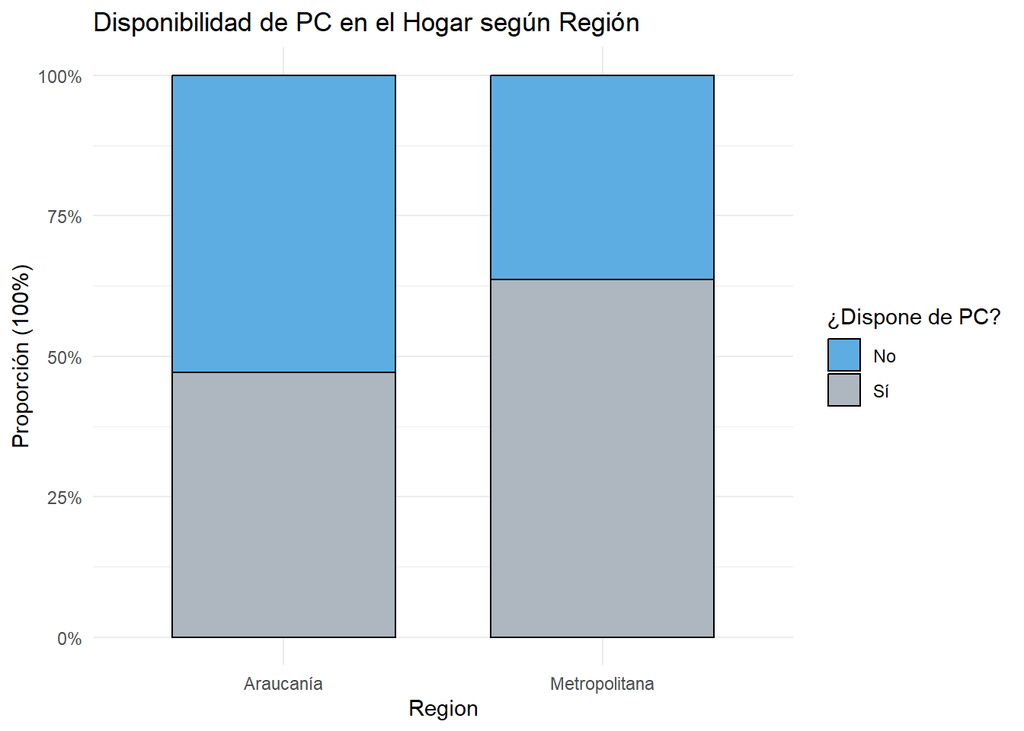

```r
# Crear un data frame con los datos exactos observados en tu muestra
datos_grafico <- data.frame(
  Region = c("Araucanía", "Araucanía", "Metropolitana", "Metropolitana"),
  Disponibilidad = c("Sí", "No", "Sí", "No"),
  Cantidad = c(33, 37, 35, 20)
)

# Gráfico de barras apiladas al 100% usando ggpubr / ggplot2
ggbarplot(datos_grafico,
          x = "Region",
          y = "Cantidad",
          fill = "Disponibilidad",
          palette = c("#5DADE2", "#AEB6BF"),
          position = position_fill(),
          title = "Disponibilidad de PC en el Hogar según Región",
          ylab = "Proporción (100%)",
          legend.title = "¿Dispone de PC?") +
  theme_minimal() +
  scale_y_continuous(labels = scales::percent)
```

#### **Verificación de condiciones para una prueba de permutaciones**

La prueba de permutaciones es un método no paramétrico de remuestreo exacto que no requiere el cumplimiento de supuestos de normalidad o tamaños muestrales mínimos por celda, los cuales son necesarios en las pruebas paramétricas tradicionales.

Para que esta prueba sea válida, solo debe cumplirse la condición de intercambiabilidad: bajo la hipótesis nula ($H_0$), la etiqueta de pertenencia regional de un hogar (“Metropolitana” o “Araucanía”) no influye en la probabilidad de que posea un computador en funcionamiento. Por lo tanto, cualquier asignación de las observaciones a los grupos es igualmente probable bajo la hipótesis nula, justificando que podamos permutar las etiquetas de los grupos repetidamente.

#### **Estadístico de interés**

El estadístico de interés seleccionado para contrastar nuestras hipótesis es la diferencia entre las proporciones muestrales de disponibilidad de computador de ambos grupos ($\hat{p}_{RM} - \hat{p}_A$).

```r
# Cálculo de proporciones observadas
props_obs <- muestra_p1 %>%
  group_by(region_txt) %>%
  summarise(prop = mean(dispone_pc == "Sí"))

p_RM_obs <- props_obs %>% filter(region_txt == "Metropolitana") %>% pull(prop)
p_A_obs <- props_obs %>% filter(region_txt == "Araucanía") %>% pull(prop)

# Si alguna región no quedó en la muestra (caso extremo), asignamos 0
if(length(p_RM_obs) == 0) p_RM_obs <- 0
if(length(p_A_obs) == 0) p_A_obs <- 0

# Diferencia observada (Estadístico observado)
dif_obs_p1 <- p_RM_obs - p_A_obs
dif_obs_p1
```

```
## [1] 0.1649351
```

#### **Prueba de permutaciones Monte Carlo**

Para determinar si la diferencia observada es estadísticamente significativa, realizamos una aproximación de Monte Carlo con $B = 5999$ permutaciones. En cada iteración barajamos aleatoriamente las etiquetas de las regiones para construir la distribución nula del estadístico de interés. A partir de estas mismas permutaciones, construimos también un intervalo de confianza para la diferencia de proporciones.

```r
B_p1 <- 5999
dif_perm <- numeric(B_p1)

variable_respuesta <- muestra_p1$dispone_pc
etiquetas_grupo <- muestra_p1$region_txt

set.seed(884) # Semilla interna para asegurar la reproducibilidad de las permutaciones
for(i in 1:B_p1) {
  # Permutación de las etiquetas de grupo
  grupos_permutados <- sample(etiquetas_grupo)

  # Proporciones bajo permutación
  p_RM_perm <- mean(variable_respuesta[grupos_permutados == "Metropolitana"] == "Sí")
  p_A_perm <- mean(variable_respuesta[grupos_permutados == "Araucanía"] == "Sí")

  dif_perm[i] <- p_RM_perm - p_A_perm
}

# Cálculo del p-valor bilateral (dos colas)
p_valor_p1 <- mean(abs(dif_perm) >= abs(dif_obs_p1))
p_valor_p1
```

```
## [1] 0.07067845
```

```r
# Intervalo de confianza al 95% para la diferencia bajo H0 usando las remuestras
ic_perm <- quantile(dif_perm, probs = c(0.025, 0.975))
ic_perm
```

```
##       2.5%      97.5%
## -0.1922078  0.1649351
```

#### **Conclusión**

A partir de los resultados obtenidos mediante la prueba de permutaciones de Monte Carlo, con $B = 5999$ permutaciones y utilizando un nivel de significación de $\alpha = 0{,}05$, observamos lo siguiente:

El estadístico de interés observado en nuestra muestra (diferencia de proporciones $\hat{p}_{RM} - \hat{p}_A$) es de $0{,}1649$ (es decir, una diferencia de un $16{,}49\%$ a favor de la Región Metropolitana).

El $p$-valor bilateral obtenido de la simulación de Monte Carlo es de $0{,}0707$ (aproximadamente $7{,}07\%$).

El intervalo de confianza al $95\%$ para la diferencia de proporciones bajo el supuesto de la hipótesis nula ($H_0$) es de $[-0{,}1922;\, 0{,}1649]$.

Dado que el $p$-valor obtenido ($0{,}0707$) es mayor que nuestro nivel de significación establecido ($\alpha = 0{,}05$), no se dispone de evidencia suficiente para rechazar la hipótesis nula ($H_0$) en favor de la hipótesis alternativa ($H_A$).

En consecuencia, no podemos concluir de manera estadísticamente significativa que exista una diferencia en la proporción de hogares que disponen de un computador en uso y funcionamiento entre la Región Metropolitana de Santiago y la Región de La Araucanía.

# Pregunta 2

#### **Pregunta de investigación**

¿Es similar, en promedio, el ingreso total corregido del hogar (ytotcorh) entre hogares cuyo jefe o jefa de hogar tiene distinto nivel educacional alcanzado (educación básica completa, educación media completa o educación superior completa)?

#### **Hipótesis**

Sea $\mu_B$ (básica completa), $\mu_M$ (educación media completa)y $\mu_S$ (educación superior completa) el ingreso total del hogar promedio de la población de hogares cuyo jefe/a de hogar tienen distintos niveles de educativo respectivamente. Entonces las hipótesis planteadas son:

- $H_0$: $\mu_B = \mu_M = \mu_S$ *El ingreso total del hogar promedio es igual entre los tres grupos educacionales*.
- $H_A$: Al menos uno de los grupos educacionales tiene un ingreso total del hogar promedio distinto a los demás ($\exists\, i \neq j$ tal que $\mu_i \neq \mu_j$).

Se trabajará con un nivel de significación $\alpha = 0{,}05$.

#### **Obtención y descripción de la muestra**

```r
set.seed(2024)  # Se establece una semilla para garantizar la reproducibilidad de los datos

# Se agrupan las categorías de "educ" en tres niveles educacionales y se
# Se descartan los hogares sin nivel educacional definido o sin ingreso.
datos_p2 <- datos %>%
  filter(educ %in% c("Básica Compl.", "M. Hum. Completa", "M. Téc Completa",
                      "Profesional Completo",
                      "Técnico Nivel Superior Completo")) %>%
  mutate(nivel_educ = case_when(
    educ == "Básica Compl." ~ "Básica completa",
    educ %in% c("M. Hum. Completa", "M. Téc Completa") ~ "Media completa",
    educ %in% c("Profesional Completo",
                "Técnico Nivel Superior Completo") ~ "Superior completa"
  )) %>%
  mutate(nivel_educ = factor(nivel_educ,
                              levels = c("Básica completa", "Media completa",
                                         "Superior completa"))) %>%
  filter(!is.na(ytotcorh)) %>%
  select(id.vivienda, nivel_educ, ytotcorh)

# Muestra aleatoria de hogares (200 < n < 300)
n <- 250
muestra <- datos_p2 %>% sample_n(n)

table(muestra$nivel_educ)
```

```
##
##   Básica completa    Media completa Superior completa
##                56               120                74
```

```r
muestra %>%
  group_by(nivel_educ) %>%
  summarise(media = mean(ytotcorh), sd = sd(ytotcorh), n = n())
```

```
## # A tibble: 3 × 4
##   nivel_educ           media       sd     n
##   <fct>                <dbl>    <dbl> <int>
## 1 Básica completa    914137.  849602.    56
## 2 Media completa    1034861.  711515.   120
## 3 Superior completa 1719727. 1505452.    74
```

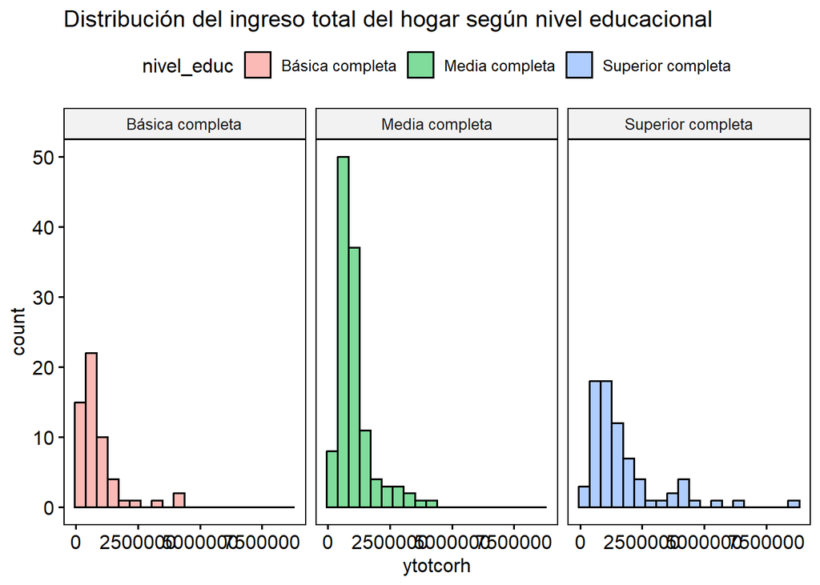

```r
# Inspección gráfica de la distribución del ingreso en cada grupo
gghistogram(muestra, x = "ytotcorh", facet.by = "nivel_educ", bins = 20,
            fill = "nivel_educ") +
  ggtitle("Distribución del ingreso total del hogar según nivel educacional")
```

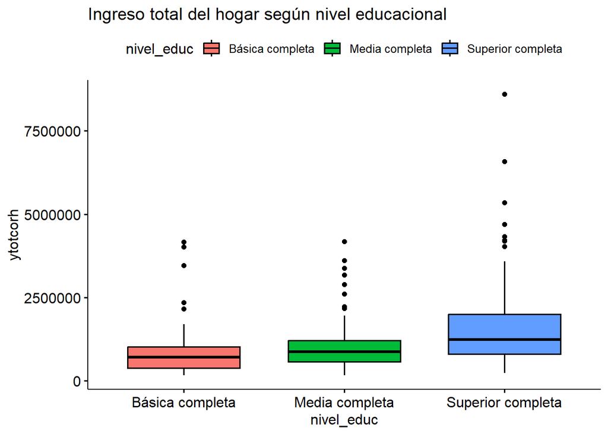

```r
ggboxplot(muestra, x = "nivel_educ", y = "ytotcorh", fill = "nivel_educ") +
  ggtitle("Ingreso total del hogar según nivel educacional")
```

#### **Verificación de condiciones para una prueba paramétrica (ANOVA clásico)**

```r
muestra %>%
  group_by(nivel_educ) %>%
  summarise(p_valor_shapiro = shapiro.test(ytotcorh)$p.value)
```

```
## # A tibble: 3 × 2
##   nivel_educ        p_valor_shapiro
##   <fct>                       <dbl>
## 1 Básica completa          1.60e- 9
## 2 Media completa           1.42e-11
## 3 Superior completa        5.43e-10
```

#### **Estadístico de interés**

- Para la prueba ómnibus se utiliza el estadístico $F$ del ANOVA de una vía (razón entre la variabilidad del ingreso promedio explicada por el nivel educacional y la variabilidad dentro de cada grupo). Y para el análisis post-hoc se utilizan las diferencias de las medias muestrales de ingreso entre cada par de niveles educacionales.

```r
# F observado (con los datos originales, sin remuestrear)
aov_obs <- aov(ytotcorh ~ nivel_educ, data = muestra)
F_obs <- summary(aov_obs)[[1]][["F value"]][1]
F_obs
```

```
## [1] 12.94121
```

```r
# Diferencias de medias observadas entre cada par de grupos
pares <- combn(levels(muestra$nivel_educ), 2, simplify = FALSE)

medias_obs <- muestra %>%
  group_by(nivel_educ) %>%
  summarise(media = mean(ytotcorh))

dif_obs <- sapply(pares, function(p) {
  medias_obs$media[medias_obs$nivel_educ == p[2]] -
    medias_obs$media[medias_obs$nivel_educ == p[1]]
})
names(dif_obs) <- sapply(pares, paste, collapse = " - ")
dif_obs
```

```
##    Básica completa - Media completa Básica completa - Superior completa
##                            120724.1                            805590.0
##  Media completa - Superior completa
##                            684866.0
```

#### **Bootstrapping: prueba ómnibus y análisis post-hoc**

Se construye la distribución nula del estadístico $F$ mediante bootstrap:

Se centra el ingreso de cada grupo restando su propia media y sumando la media genera, así de esta, manera las tres muestras queden con medias iguales, lo que es consistente con $H_0$, luego se remuestrea con reemplazo y dentro de cada grupo desde estos datos centrados. En cada una de las B réplicas se calcula tanto el estadístico $F$ (prueba ómnibus) como las diferencias de medias entre cada par de grupos (post-hoc), asegurando así que el análisis post-hoc usa exactamente las mismas remuestras que la prueba ómnibus.

```r
grupo <- muestra$nivel_educ
y <- muestra$ytotcorh
niveles <- levels(grupo)

# Datos centrados bajo el supuesto de H0 (medias iguales entre grupos)
media_general <- mean(y)
y_centrado <- y - ave(y, grupo, FUN = mean) + media_general

B <- 2000  # número de remuestra del bootstrap
F_boot <- numeric(B)
dif_boot <- matrix(NA, nrow = B, ncol = length(pares))

set.seed(321)
for (i in 1:B) {
  y_star <- c()
  grupo_star <- c()

  # Remuestreo con reemplazo, por separado dentro de cada grupo, asi se mantener fijo el tamaño de cada grupo en cada réplica
  for (g in niveles) {
    y_g <- y_centrado[grupo == g]
    y_star <- c(y_star, sample(y_g, length(y_g), replace = TRUE))
    grupo_star <- c(grupo_star, rep(g, length(y_g)))
  }
  grupo_star <- factor(grupo_star, levels = niveles)
  datos_star <- data.frame(y = y_star, grupo = grupo_star)

  # Estadístico F de la remuestra (prueba ómnibus)
  aov_star <- aov(y ~ grupo, data = datos_star)
  F_boot[i] <- summary(aov_star)[[1]][["F value"]][1]

  # Diferencias de medias de la misma remuestra (post-hoc)
  medias_star <- tapply(y_star, grupo_star, mean)
  dif_boot[i, ] <- sapply(pares, function(p) medias_star[p[2]] - medias_star[p[1]])
}

p_valor_omnibus <- mean(F_boot >= F_obs)
p_valor_omnibus
```

```
## [1] 0
```

```r
p_valores_posthoc <- sapply(seq_along(pares), function(j) {
  mean(abs(dif_boot[, j]) >= abs(dif_obs[j]))
})
names(p_valores_posthoc) <- names(dif_obs)
p_valores_posthoc
```

```
##    Básica completa - Media completa Básica completa - Superior completa
##                              0.3445                              0.0000
##  Media completa - Superior completa
##                              0.0010
```

```r
# Se aplica una corrección por comparaciones múltiples (Bonferroni), ya que se están realizando tres comparaciones de a pares a partir de las mismas remuestras
p_valores_ajustados <- p.adjust(p_valores_posthoc, method = "bonferroni")
p_valores_ajustados
```

```
##    Básica completa - Media completa Básica completa - Superior completa
##                               1.000                               0.000
##  Media completa - Superior completa
##                               0.003
```

*La compilación del html puede tardar un poco por el Bootstrapping*

#### **Conclusión**

Se puede concluir con un nivel de significandia de $\alpha = 0{,}05$ y dado que el p-valor obtenido para la prueba ómnibus de bootstrap es menor que $\alpha$, que se rechaza $H_0$ en favor de $H_A$, por lo que existen diferencias significativas en el ingreso total del hogar promedio entre al menos dos de los niveles educacionales del jefe o jefa de hogar considerados.

El análisis post-hoc con bootstrap muestra que las diferencias significativas se concentran en las comparaciones que involucran a los hogares con educación superior completa, tanto la comparación Básica completa - Superior completa como Media completa - Superior completa resultan ser significativas, por otro lado la diferencia hallada entre el nivel de educación Básica completa y Media completa no representa ser una diferencia significativa. En otras palabras, contar con un jefe o jefa de hogar con educación superior completa está asociado a un ingreso total del hogar promedio significativamente mayor que en los hogares donde el jefe o jefa de hogar tiene educación básica o media completa, pero no se observan diferencias significativas entre estos dos últimos grupos entre sí.